# TP1 – Analyse de Fourier

- Montrer tout le code
- Cacher tout le code
- Voir les sources

Auteur·rice

HAMLIL Mohamed

Date de publication

2024

# TP1 – Analyse de Fourier

Ce notebook présente les exercices du TP1 en R. Les extraits de code sont basés sur le document fourni et comprennent des commentaires pour expliquer chaque étape.

## 1. Les complexes

Dans cette section, nous manipulons des nombres complexes en R. Pour créer l’unité imaginaire, on utilise `1i`.

```r
# Définition de deux nombres complexes
z1 <- 1 + 3*1i  # 1 + 3i
z2 <- 3*1i + 4   # 4 + 3i

# Opérations algébriques de base
z1 + z2       # addition de z1 et z2
```

```
[1] 5+6i
```

```r
z1 + 3*z2     # addition de z1 avec trois fois z2
```

```
[1] 13+12i
```

```r
z1 * z2       # produit des deux complexes
```

```
[1] -5+15i
```

```r
z1^2          # puissance : z1 au carré
```

```
[1] -8+6i
```

```r
z1 / z2       # division de z1 par z2
```

```
[1] 0.52+0.36i
```

```r
# Fonctions intégrées pour récupérer la partie réelle, imaginaire, l’argument et le module
a <- Re(z1)       # partie réelle de z1
b <- Im(z1)       # partie imaginaire de z1
theta <- Arg(z1)  # argument (angle) de z1
r <- Mod(z1)       # module (longueur) de z1

# Créer un complexe à partir de ses parties réelle et imaginaire
complex(real = a, imaginary = b)
```

```
[1] 1+3i
```

```r
# Vérifier la forme trigonométrique
r * (cos(theta) + sin(theta) * 1i)
```

```
[1] 1+3i
```

```r
# Vérifier la forme exponentielle
r * exp(theta * 1i)
```

```
[1] 1+3i
```

## 2.1 Intégrer une fonction

Nous calculons l’intégrale de `arctan(x)` sur l’intervalle $[0, 1]$ à l’aide de la fonction `integrate`.

```r
# Définir la fonction à intégrer
f <- function(x) { atan(x) }

# Calculer l’intégrale sur [0,1]
integrate(f, lower = 0, upper = 1)
```

```
0.4388246 with absolute error < 4.9e-15
```

```r
# Pour extraire uniquement la valeur numérique (sans l’erreur)
integrate(f, lower = 0, upper = 1)$value
```

```
[1] 0.4388246
```

```r
# Si la fonction est complexe, on sépare la partie réelle et imaginaire
ref <- function(x) { Re(f(x)) }
imf <- function(x) { Im(f(x)) }
# Combiner les deux pour obtenir une valeur complexe
integrate(ref, 0, 1)$value + 1i * integrate(imf, 0, 1)$value
```

```
[1] 0.4388246+0i
```

## 2.2 La fonction

On définit une fonction périodique de période 2 sur l’intervalle $[-1, 1]$.

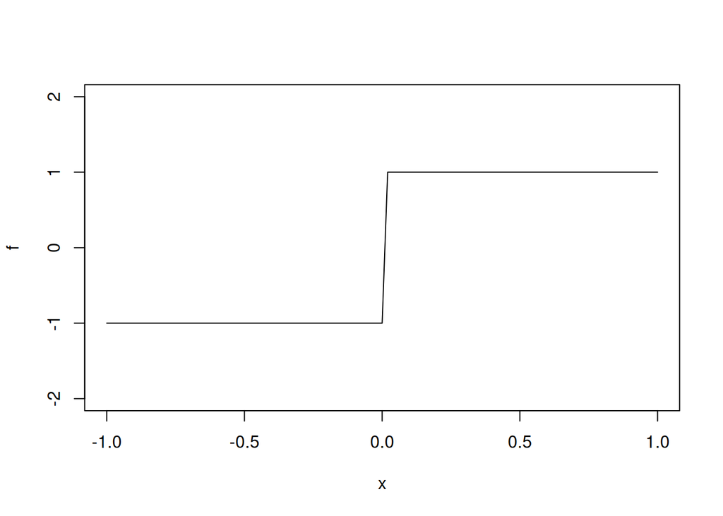

```r
# Définition d’une fonction 2‑périodique définie sur [−1,1]
f <- function(x) { 2 * as.numeric(x > 0) - 1 }  # renvoie 1 si x>0, −1 sinon

# Traçage de la fonction sur une fenêtre plus large
plot(f, xlim = c(-1, 1), ylim = c(-2, 2))
```

```r
# Note : il ne devrait pas y avoir de barre verticale au milieu du tracé car f(0) = −1
```

## 2.3 Coefficients de la série de Fourier

Cette fonction `coeff` calcule le coefficient de la série de Fourier pour une fonction `f` et un entier `n`.

```r
# Fonction pour calculer le n‑ième coefficient de Fourier
coeff <- function(f, n) {
  e <- function(x, n) { exp(pi * 1i * n * x) }            # fonction exponentielle complexe
  g <- function(x) { f(x) * Conj(e(x, n)) }               # produit de f et du conjugué de e
  reg <- function(x) { Re(g(x)) }                         # partie réelle
  img <- function(x) { Im(g(x)) }                         # partie imaginaire
  0.5 * integrate(reg, -1, 1)$value + 0.5i * integrate(img, -1, 1)$value  # coefficient
}

# Exemple : tester pour quelques valeurs de n
coeff(f, 0)  # coefficient c0
```

```
[1] 0+0i
```

```r
coeff(f, 1)  # coefficient c1
```

```
[1] 0-0.6366198i
```

```r
coeff(f, -1) # coefficient c−1
```

```
[1] 0+0.6366198i
```

## 2.4 Convergence de la série de Fourier

On définit la fonction `SN` qui calcule la somme partielle de la série de Fourier pour l’ordre `N`. Nous traçons les sommes partielles pour différentes valeurs de `N`.

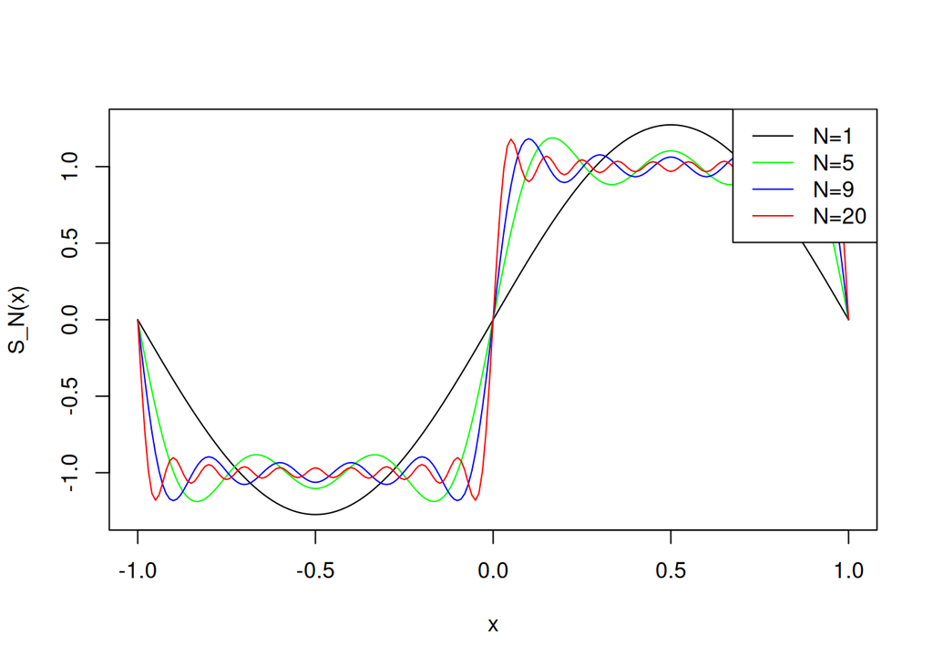

```r
# Fonction SN pour calculer la somme partielle de la série de Fourier
SN <- function(f, N, x) {
  S <- coeff(f, 0)  # terme constant
  for (n in 1:N) {
    # Ajout des termes positifs et négatifs
    S <- S + coeff(f, n) * exp(pi * 1i * n * x) + coeff(f, -n) * exp(-pi * 1i * n * x)
  }
  S
}

# Discrétisation de l’intervalle pour le tracé
discr <- seq(-1, 1, 0.01)

# Tracer les sommes partielles pour différentes valeurs de N
plot(discr, SN(f, 1, discr), type = "l", col = "black", ylab = "S_N(x)", xlab = "x")
lines(discr, SN(f, 5, discr), col = "green")
lines(discr, SN(f, 9, discr), col = "blue")
lines(discr, SN(f, 20, discr), col = "red")
legend("topright", legend = c("N=1", "N=5", "N=9", "N=20"), col = c("black", "green", "blue", "red"), lty = 1)
```

## 3. Travail à rendre (adaptation)

```r
g <- function(x) { alpha * x + 1 }
# Adapter coeff() en changeant l’intervalle d’intégration de −π à π
# et en tenant compte de la nouvelle période 2π
```